# Assignment 12: Predictive Modeling - Part 3

*How to do it?*:

- Open the Rmarkdown file of this assignment (link) in Rstudio.
- Right under each **question**, insert a code chunk (you can use the hotkey `Ctrl + Alt + I` to add a code chunk) and code the solution for the question.
- `Knit` the rmarkdown file (hotkey: `Ctrl + Alt + K`) to export an html.
- Publish the html file to your Githiub Page.

*Submission*: Submit the link on Github of the assignment to Blackboard.

1. Use the `PimaIndiansDiabetes` dataset. Use 15% data for testing. Use cross-validation with of 7 folds to tune random forest `(method='ranger')`. What are the parameters that produce the greatest accuracy? What is the testing accuracy.

```r
library(mlbench)
library(tidyverse)
data(PimaIndiansDiabetes)
df <- tibble(PimaIndiansDiabetes)

library(caret)
df <- df %>% rename(target=diabetes)

# Remove some columns
df <- df %>% select(-pressure, -triceps, -mass, -pedigree)

df <- df %>%
  mutate(target = as.factor(target),
         pregnant = as.factor(pregnant),
         glucose = as.factor(glucose),
         insulin = as.factor(insulin),
         age = as.factor(age)
         )

df$age[is.na(df$age)] = mean(df$age, na.rm = TRUE)
df = drop_na(df)

set.seed(2020)
splitIndex <- createDataPartition(df$target, p = .85,
                                  list = FALSE)
df_train <- df[ splitIndex,]
df_test <- df[-splitIndex,]

getModelInfo('ranger')$ranger$parameters
```

```
##       parameter     class                         label
## 1          mtry   numeric #Randomly Selected Predictors
## 2     splitrule character                Splitting Rule
## 3 min.node.size   numeric             Minimal Node Size
```

```r
trControl = trainControl(method = "cv",
                         number = 7)
tuneGrid = expand.grid(mtry = 2:4,
                       splitrule = c('gini', 'extratrees'),
                       min.node.size = c(1:10))
forest_ranger <- train(target~., data=df_train,
                    method = "ranger",
                    trControl = trControl,
                    tuneGrid = tuneGrid)

pred <- predict(forest_ranger, df_test)
cm <- confusionMatrix(data = pred, reference = df_test$target, positive = "pos")
cm$overall[1]
```

```
##  Accuracy
## 0.6608696
```

Mentioned above is the testing accuracy.

```r
print(forest_ranger)
```

```
## Random Forest
##
## 653 samples
##   4 predictor
##   2 classes: 'neg', 'pos'
##
## No pre-processing
## Resampling: Cross-Validated (7 fold)
## Summary of sample sizes: 560, 561, 559, 560, 559, 559, ...
## Resampling results across tuning parameters:
##
##   mtry  splitrule   min.node.size  Accuracy   Kappa
##   2     gini         1             0.6508531  0.000000000
##   2     gini         2             0.6508531  0.000000000
##   2     gini         3             0.6508531  0.000000000
```

[output cut: 61 more lines]

Mentioned above are the parameters that produce the greatest accuracy.

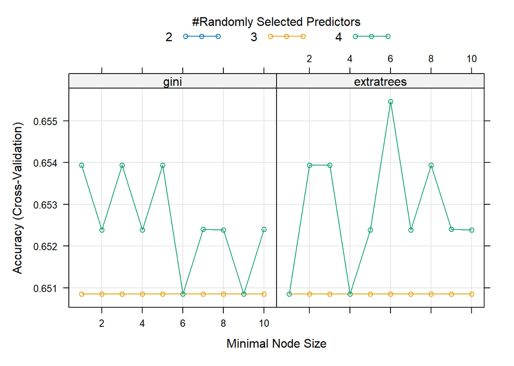

```r
plot(forest_ranger)
```

2. Use the `PimaIndiansDiabetes` dataset. Go to https://topepo.github.io/caret/available-models.html and pick a classification model. Tune the classification model using cross-validation of 7 folds.

```r
library(xgboost)
library(caret)

trControl <- trainControl(method = "cv", number = 7, verboseIter = TRUE)
tuneGrid <- expand.grid(
  nrounds = c(100, 200, 300),
  max_depth = c(3, 6, 9),
  eta = c(0.01, 0.1, 0.3),
  gamma = 0,
  colsample_bytree = 1,
  min_child_weight = 1,
  subsample = 1
)

xgb_model <- train(
  target ~ ., data = df_train,
  method = "xgbTree",
  trControl = trControl,
  tuneGrid = tuneGrid
)
```

[output not shown]

[output cut: 72 more lines]

[output not shown]

```r
pred <- predict(xgb_model, df_test)
cm <- confusionMatrix(data = pred, reference = df_test$target, positive = "pos")
cm$overall[1]
```

```
##  Accuracy
## 0.7130435
```

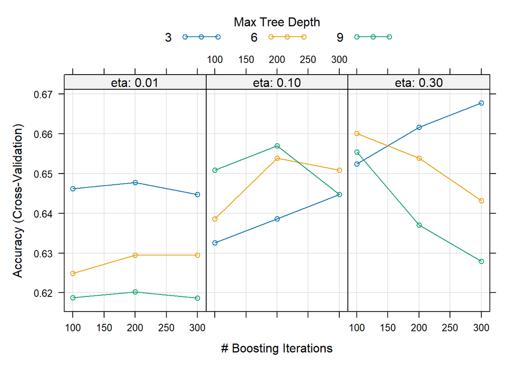

```r
plot(xgb_model)
```

3. (Model Comparison) Use the `PimaIndiansDiabetes` dataset. Pick two models at [this link](https://topepo.github.io/caret/available-models.html) to compare using 7-fold cross validation method. Evaluate the accuracy of the final model on the test data.

```r
library(glmnet)
library(caret)

trControl <- trainControl(method = "cv", number = 7, verboseIter = TRUE)

tuneGrid <- expand.grid(
  alpha = 0:1,
  lambda = 10^seq(-4, 4, length.out = 9)
)

glm_model <- train(
  target ~ ., data = df_train,
  method = "glmnet",
  trControl = trControl,
  tuneGrid = tuneGrid
)
pred <- predict(glm_model, df_test)
cm <- confusionMatrix(data = pred, reference = df_test$target, positive = "pos")
cm$overall[1]
```

```
##  Accuracy
## 0.6521739
```

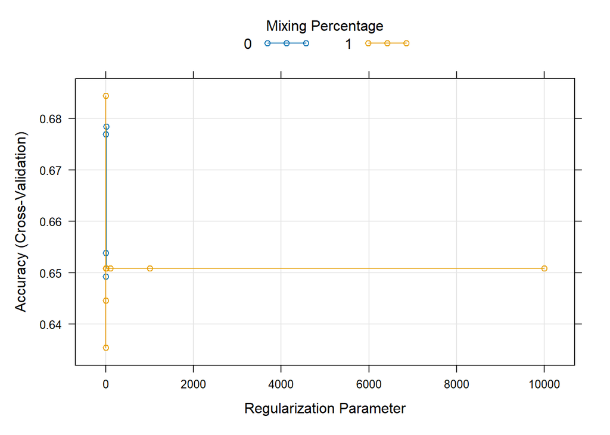

```r
plot(glm_model)
```

```r
library(gbm)

trControl <- trainControl(method = "cv", number = 7, verboseIter = TRUE)

tuneGrid <- expand.grid(
  n.trees = c(100, 200, 300),
  interaction.depth = c(3, 6, 9),
  shrinkage = c(0.01, 0.1, 0.3),
  n.minobsinnode = c(10, 20, 30)
)

gbm_model <- train(
  target ~ ., data = df_train,
  method = "gbm",
  trControl = trControl,
  tuneGrid = tuneGrid
)
pred <- predict(gbm_model, df_test)
cm <- confusionMatrix(data = pred, reference = df_test$target, positive = "pos")
cm$overall[1]
```

```
##  Accuracy
## 0.7217391
```

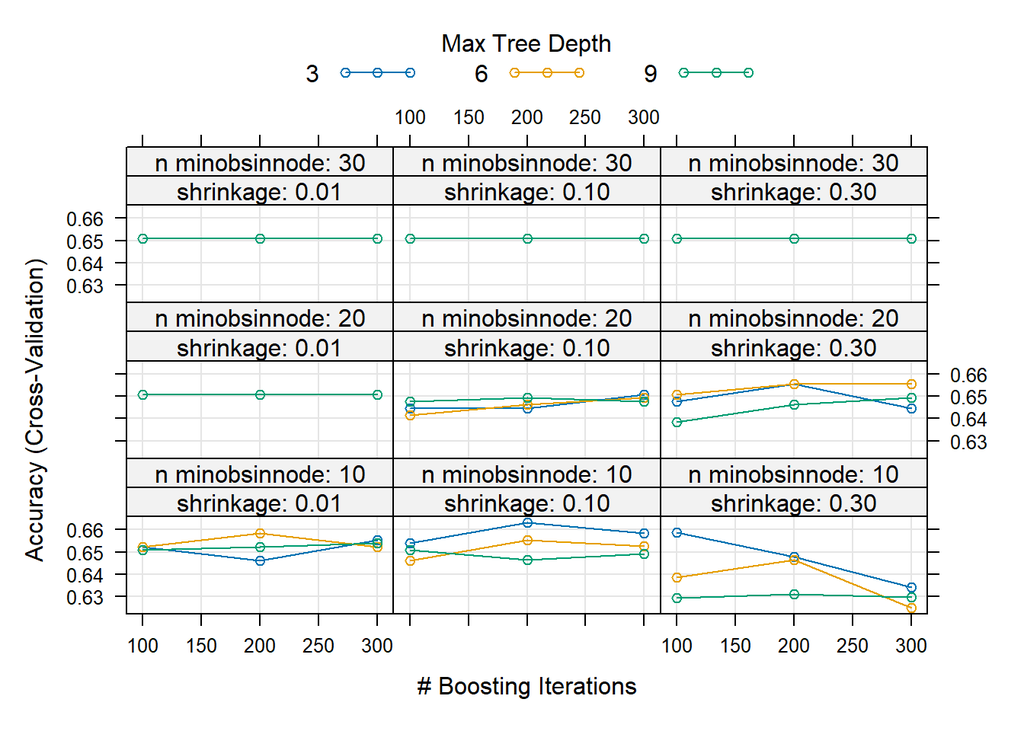

```r
plot(gbm_model)
```

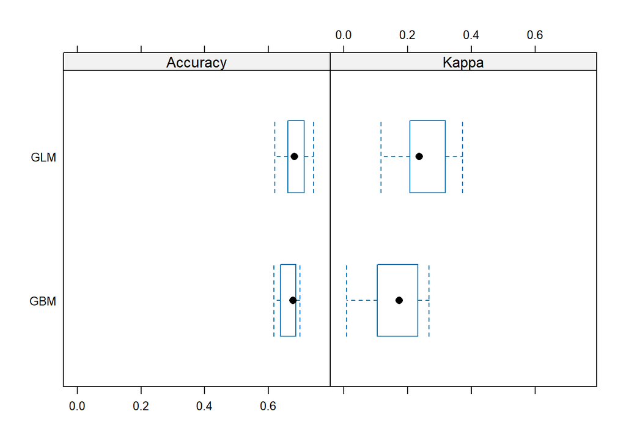

```r
results <- resamples(list('GLM' = glm_model,
                          'GBM' = gbm_model))
bwplot(results)
```